# Matrix Population Modelling practical

### Hannah Froy

We will use the *popbio* package for our matrix population modelling today. Install this and load it into your workspace, along with the *ggplot2* package for plotting.

```r
rm(list=ls(all=TRUE))

my_packages <- c('ggplot2', 'popbio')
new_packages <- my_packages[!(my_packages %in% installed.packages()[,'Package'])]
if(length(new_packages)) install.packages(new_packages, dependencies = T)

library(ggplot2)
library(popbio)
```

## Parameterising your Matrix Population Model (MPM)

### Stage-specific survival

Using the same approach as we used on Tuesday, I ran a Cormack–Jolly–Seber model in package *marked* to estimate the survival rates of Juveniles, Yearlings and Adults 2+. Comparing a model with and without time-varying detection probabilities, I found evidence that detection probability varied among years. I therefore used time-varying detection probabilities when estimating the stage-specific survival rates, which were as follows:  
• Juvenile survival: 0.463 (95% CI 0.404–0.524)  
• Yearling survival: 0.510 (95% CI 0.445–0.574)  
• Adult 2+ survival: 0.559 (95% CI 0.499–0.618)

Let’s plot these survival rates.

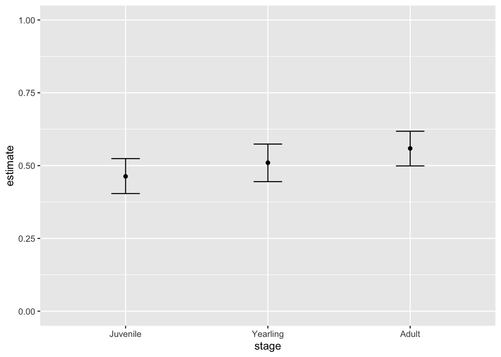

```r
# first enter the values into a dataframe
survival <- data.frame(stage=factor(c('Juvenile','Yearling','Adult'), levels=c('Juvenile','Yearling','Adult')), estimate=c(0.463, 0.510, 0.559), lcl=c(0.404, 0.445, 0.499), ucl=c(0.524, 0.574, 0.618))

# then plot by stage
ggplot(survival, aes(stage, estimate, ymin=lcl, ymax=ucl)) +
  geom_errorbar(width=0.2) + geom_point() + ylim(0,1)
```

#### *QUESTION: Which stage has the lowest survival rate? Is this what you would expect?*

### Per captia reproduction

We need to estimate the number of (female) offspring produced by each female between censuses. This information can be gathered from the nest visitation data. Load this data for Gjeroy for 1998-2012, and have a look at the dataset. (Edit the file path to direct R to wherever you saved the data file).

```r
nestdata <- read.table("~/Dropbox/Hannah/Work URF/Teaching/MSc/Practicals/MPM/gjeroynest.txt", header = TRUE, sep = '\t')
head(nestdata)
```

```
##   nestid year clutchno hatchingsuc chickno
## 1   5795 1998        1           0       0
## 2   1187 1998        1           1       4
## 3   7190 1998        2           1       4
## 4   1751 1998        1           0       0
## 5   3499 1998        1           1       4
## 6   5355 1998        2           1       3
```

*clutchno* indicates whether it was the first, second or third etc. clutch laid in that nest in that breeding season. *hatchingsuc* indicates whether any live chicks were found for that clutch (yes = 1; no = 0). *chickno* indicates the number of chicks counted on the final visit prior to fledging.

#### *QUESTION: How might you estimate per capita reproduction from these data?*

**Click me**

We have information on the average number of clutches, the average hatching success of those clutches, and the average number of chicks within a clutch prior to fledging. We can get these using the mean() function.

```r
ClutchNo <- mean(nestdata$clutchno)
HatchingSuc <- mean(nestdata$hatchingsuc)
FledglingNo <- mean(nestdata$chickno)
```

We can use these as estimates of Clutch Number, Hatching Success and Fledgling Number to calculate per capita reproduction. (Note! The mean number of chicks prior to fledging is an upwardly biased estimate of the number of fledglings, since not all will likely fledge the nest successfully).

We then take the average number of clutches (Clutch Number) and multiply that by the probability of a clutch hatching (Hatching Success), multiplied by the expected number of fledglings (Fledgling Number). This gives us the expected number of chicks per female over the breeding season. Since we are modelling only the *female* segment of the population, we will then divide this estimate by 2 to get the number of female chicks (assuming an equal sex ratio of offspring).

```r
(ClutchNo * HatchingSuc * FledglingNo) / 2
```

```
## [1] 0.9744764
```

• Our estimate of per capita reproduction R is 0.974.

## Deterministic population model

In the first part of this practical, we determined the structure of our Matrix Population Model. We now have the numbers we need to parameterise a deterministic model. We need a 3x3 matrix with the fertility transitions along the top row, and the survival transitions on the subsequent rows.

```r
# save our estimates of the vital rates
R <- (ClutchNo * HatchingSuc * FledglingNo) / 2
Phi.juv <- survival$estimate[survival$stage=='Juvenile']
Phi.yr <- survival$estimate[survival$stage=='Yearling']
Phi.ad <- survival$estimate[survival$stage=='Adult']

# remind ourselves how these relate to the transition probabilities of the matrix (see slides)
# Juvenile to Juvenile: Phi.juv * R
# Yearling to Juvenile: Phi.yr * R
# Adult to Juvenile: Phi.ad * R
# Juvenile to Yearling: Phi.juv
# Yearling to Yearling: 0
# Adult to Yearling: 0
# Juvenile to Adult: 0
# Yearling to Adult: Phi.yr
# Adult to Adult: Phi.ad

# put the transition probabilities into a vector
sparrowMPM <- c(Phi.juv * R, Phi.yr * R, Phi.ad * R, Phi.juv, 0, 0, 0, Phi.yr, Phi.ad)

# save that vector as a matrix, specifying the number of rows and columns
# use the byrow=TRUE argument to tell R that the first the elements of the vector correspond to the first row of the matrix
sparrowMPM <- matrix(sparrowMPM, nrow=3, ncol=3, byrow=T)
sparrowMPM
```

```
##           [,1]     [,2]      [,3]
## [1,] 0.4511826 0.496983 0.5447323
## [2,] 0.4630000 0.000000 0.0000000
## [3,] 0.0000000 0.510000 0.5590000
```

We can now use the *popbio* package to do some analyses of our deterministic MPM. For example, we can look at the population growth rate, lambda. (Just for background info- lambda is calculated as the *dominant eigenvalue* of our matrix using matrix algebra).

```r
lambda(sparrowMPM)
```

```
## [1] 0.9878016
```

```r
# 0.9878016
```

#### *QUESTION: What does this tell us about they dynamics of our sparrow population?*

### Projected dynamics

**Click me**

We can project the dynamics over a given number of iterations (t) based on our matrix and a starting population (n0).

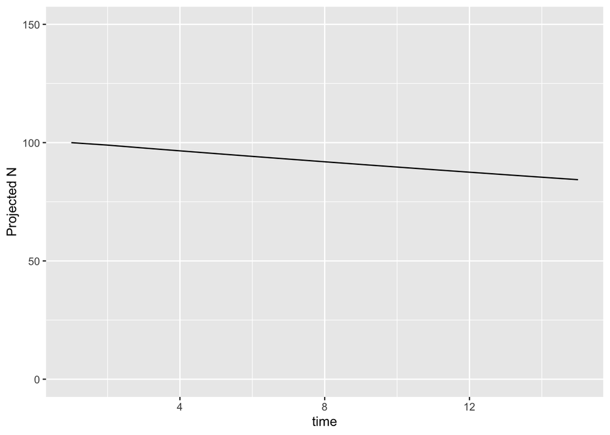

```r
# project over 15 years
t <- 15
# start with 50 juveniles, 20 yearlings and 30 adults
n0 <- c(50,20,30)

# project dynamics
projection <- pop.projection(sparrowMPM, n0, iterations = t)
projected <- data.frame(time=1:15, N=projection$pop.sizes)

# plot projected pop size over time
ggplot(projected, aes(time, N)) +
  geom_line() + ylim(0,150) + ylab('Projected N')
```

The population is projected to decline slowly over time since lambda<1.

### Observed dynamics

We can compare this with estimated population counts (N) over the 15 study years, saved in the file ‘popest.txt’. (Again, edit the file path to tell R where you saved the file).

```r
popest <- read.table("~/Dropbox/Hannah/Work URF/Teaching/MSc/Practicals/MPM/popest.txt", header = TRUE, sep = '\t')
head(popest)
```

```
##   year  N
## 1 1998 54
## 2 1999 69
## 3 2000 62
## 4 2001 52
## 5 2002 40
## 6 2003 45
```

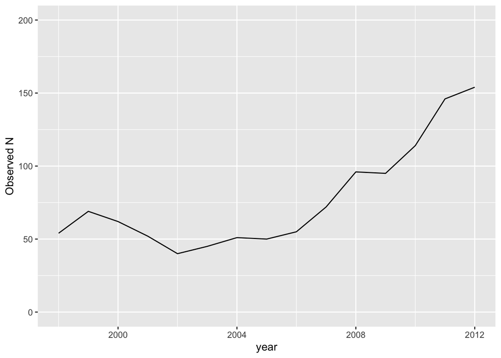

```r
# plot N over time
ggplot(popest, aes(year, N)) +
  geom_line() + ylim(0,200) + ylab('Observed N')
```

#### *QUESTION: How does this population trajectory compare with our estimate of lambda? Can you think of potential reasons for the discrepancy?*

### Stable stage distribution and reproductive value

*popbio* has built-in functions for other analyses of the asymptotic dynamics of our matrix. For example, we can look at the the *stable stage distribution* of our population, that is the long-term average relative abundance of the different stage classes. Also, the *reproductive values* of the different stage classes, that is the expected contribution of each individual in that stage class to future reproduction. (Again for background info, these care calculated as the right and left *eigenvectors* of our matrix, respectively).

```r
stages <- c('Juv','Yr','Ad')
colnames(sparrowMPM) <- stages
rownames(sparrowMPM) <- stages

stable.stage(sparrowMPM)
```

```
##       Juv        Yr        Ad
## 0.4935366 0.2313293 0.2751341
```

```r
reproductive.value(sparrowMPM)
```

```
##      Juv       Yr       Ad
## 1.000000 1.159004 1.270360
```

We could potentially compare the stable stage distribution with what we observed based on the recapture data to tell us something about the performance of our model (we won’t do this today).

### Perturbation analysis

*popbio* also includes built-in functions to calculate the sensitivities and elasticities of the different vital rates. These tell us about the relative importance of each vital rate (or matrix transition) in determining the population growth rate, lambda. Remember, sensitivities estimate the change in lambda for an *absolute* change in a vital rate, whereas elasticities tell us about the effect of a *proportional* change.

```r
# list the vital rates
sparrow.param <- list(Phi.juv = Phi.juv, Phi.yr = Phi.yr, Phi.ad = Phi.ad, R = R)

# give the matrix equation
sparrow.equation <- expression(Phi.juv * R, Phi.yr * R, Phi.ad * R, Phi.juv, 0, 0, 0, Phi.yr, Phi.ad)

# run the sensitivity analysis
sens <- vitalsens(sparrow.equation, sparrow.param)
sens
```

```
##          estimate sensitivity elasticity
## Phi.juv 0.4630000   0.9476077  0.4441604
## Phi.yr  0.5100000   0.4673430  0.2412883
## Phi.ad  0.5590000   0.5558396  0.3145514
## R       0.9744764   0.4502339  0.4441604
```

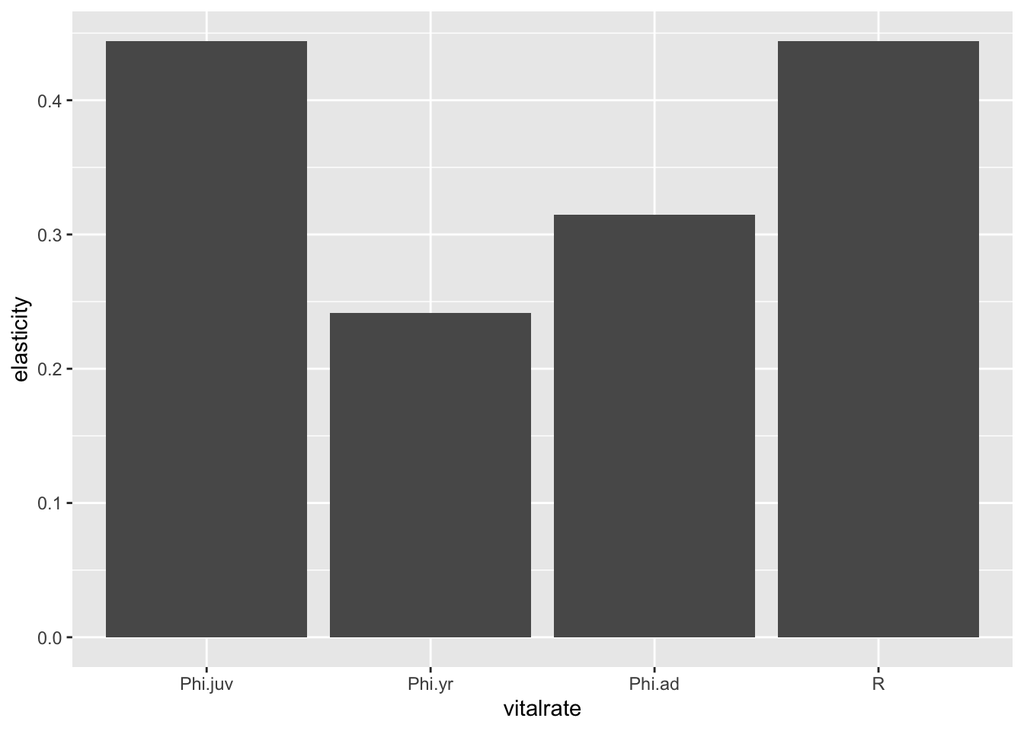

```r
# plot elasticity of the vital rates
sens$vitalrate <- factor(c('Phi.juv', 'Phi.yr', 'Phi.ad', 'R'), levels = c('Phi.juv', 'Phi.yr', 'Phi.ad', 'R'))
ggplot(sens, aes(vitalrate, elasticity)) +
  geom_bar(stat = 'identity')
```

#### *QUESTION: Which vital rates are most important for population growth? Is this similar to the orca example that we saw in the lecture? Is this what you would expect based on the life-history of the species?*